# EnsembleTechniques_Project_Ashok

```python
#Importing necessary packages
import pandas as pd
import matplotlib.pyplot as plt
import seaborn as sns
import numpy as np
import scipy.stats as stats
%matplotlib inline
from sklearn.linear_model import LogisticRegression
from sklearn import model_selection
from sklearn.model_selection import train_test_split
from sklearn.preprocessing import FunctionTransformer
from sklearn.neighbors import KNeighborsClassifier
from sklearn.naive_bayes import GaussianNB
#from sklearn.svm import SVC
from sklearn.ensemble import RandomForestClassifier
from mlxtend.classifier import StackingClassifier
from sklearn import metrics
from scipy import stats
import os
os.chdir (r"D:\anaconda\ashok\Project\EnsembleTechniques")
import warnings
warnings.filterwarnings('ignore')
```

## 1.Loading the dataset

```python
# Reading the data as a data frame
df = pd.read_csv('Data - Parkinsons')
print (df)
```

```
               name  MDVP:Fo(Hz)  MDVP:Fhi(Hz)  MDVP:Flo(Hz)  MDVP:Jitter(%)  \
0    phon_R01_S01_1      119.992       157.302        74.997         0.00784
1    phon_R01_S01_2      122.400       148.650       113.819         0.00968
2    phon_R01_S01_3      116.682       131.111       111.555         0.01050
3    phon_R01_S01_4      116.676       137.871       111.366         0.00997
4    phon_R01_S01_5      116.014       141.781       110.655         0.01284
..              ...          ...           ...           ...             ...
190  phon_R01_S50_2      174.188       230.978        94.261         0.00459
191  phon_R01_S50_3      209.516       253.017        89.488         0.00564
192  phon_R01_S50_4      174.688       240.005        74.287         0.01360
193  phon_R01_S50_5      198.764       396.961        74.904         0.00740
194  phon_R01_S50_6      214.289       260.277        77.973         0.00567

     MDVP:Jitter(Abs)  MDVP:RAP  MDVP:PPQ  Jitter:DDP  MDVP:Shimmer  ...  \
0             0.00007   0.00370   0.00554     0.01109       0.04374  ...
```

[output cut: 38 more lines]

## 2.Gathering Information about Dataset, checking for missing values & Challenges in Dataset

```python
# Information about data set
df.info()
```

```
<class 'pandas.core.frame.DataFrame'>
RangeIndex: 195 entries, 0 to 194
Data columns (total 24 columns):
 #   Column            Non-Null Count  Dtype
---  ------            --------------  -----
 0   name              195 non-null    object
 1   MDVP:Fo(Hz)       195 non-null    float64
 2   MDVP:Fhi(Hz)      195 non-null    float64
 3   MDVP:Flo(Hz)      195 non-null    float64
 4   MDVP:Jitter(%)    195 non-null    float64
 5   MDVP:Jitter(Abs)  195 non-null    float64
 6   MDVP:RAP          195 non-null    float64
 7   MDVP:PPQ          195 non-null    float64
 8   Jitter:DDP        195 non-null    float64
 9   MDVP:Shimmer      195 non-null    float64
```

[output cut: 16 more lines]

```python
# Finding Shape of data
# Inference : There are 195 rows and 24 columns of data
df.shape
```

```
(195, 24)
```

```python
# Finding Type
df.dtypes
```

```
name                 object
MDVP:Fo(Hz)         float64
MDVP:Fhi(Hz)        float64
MDVP:Flo(Hz)        float64
MDVP:Jitter(%)      float64
MDVP:Jitter(Abs)    float64
MDVP:RAP            float64
MDVP:PPQ            float64
Jitter:DDP          float64
MDVP:Shimmer        float64
MDVP:Shimmer(dB)    float64
Shimmer:APQ3        float64
Shimmer:APQ5        float64
MDVP:APQ            float64
Shimmer:DDA         float64
NHR                 float64
HNR                 float64
status                int64
RPDE                float64
DFA                 float64
spread1             float64
spread2             float64
D2                  float64
PPE                 float64
dtype: object
```

```python
# Checking presence of missing values
# Inference : There are no missing values
df.isnull()
```

|  | name | MDVP:Fo(Hz) | MDVP:Fhi(Hz) | MDVP:Flo(Hz) | MDVP:Jitter(%) | MDVP:Jitter(Abs) | MDVP:RAP | MDVP:PPQ | Jitter:DDP | MDVP:Shimmer | ... | Shimmer:DDA | NHR | HNR | status | RPDE | DFA | spread1 | spread2 | D2 | PPE |
| --- | --- | --- | --- | --- | --- | --- | --- | --- | --- | --- | --- | --- | --- | --- | --- | --- | --- | --- | --- | --- | --- |
| 0 | False | False | False | False | False | False | False | False | False | False | ... | False | False | False | False | False | False | False | False | False | False |
| 1 | False | False | False | False | False | False | False | False | False | False | ... | False | False | False | False | False | False | False | False | False | False |
| 2 | False | False | False | False | False | False | False | False | False | False | ... | False | False | False | False | False | False | False | False | False | False |
| 3 | False | False | False | False | False | False | False | False | False | False | ... | False | False | False | False | False | False | False | False | False | False |
| 4 | False | False | False | False | False | False | False | False | False | False | ... | False | False | False | False | False | False | False | False | False | False |
| ... | ... | ... | ... | ... | ... | ... | ... | ... | ... | ... | ... | ... | ... | ... | ... | ... | ... | ... | ... | ... | ... |
| 190 | False | False | False | False | False | False | False | False | False | False | ... | False | False | False | False | False | False | False | False | False | False |
| 191 | False | False | False | False | False | False | False | False | False | False | ... | False | False | False | False | False | False | False | False | False | False |
| 192 | False | False | False | False | False | False | False | False | False | False | ... | False | False | False | False | False | False | False | False | False | False |
| 193 | False | False | False | False | False | False | False | False | False | False | ... | False | False | False | False | False | False | False | False | False | False |
| 194 | False | False | False | False | False | False | False | False | False | False | ... | False | False | False | False | False | False | False | False | False | False |

195 rows × 24 columns

```python
# Checking presence of missing values
# Inference : No null values in the dataset
df.isna().apply(pd.value_counts)
```

|  | name | MDVP:Fo(Hz) | MDVP:Fhi(Hz) | MDVP:Flo(Hz) | MDVP:Jitter(%) | MDVP:Jitter(Abs) | MDVP:RAP | MDVP:PPQ | Jitter:DDP | MDVP:Shimmer | ... | Shimmer:DDA | NHR | HNR | status | RPDE | DFA | spread1 | spread2 | D2 | PPE |
| --- | --- | --- | --- | --- | --- | --- | --- | --- | --- | --- | --- | --- | --- | --- | --- | --- | --- | --- | --- | --- | --- |
| False | 195 | 195 | 195 | 195 | 195 | 195 | 195 | 195 | 195 | 195 | ... | 195 | 195 | 195 | 195 | 195 | 195 | 195 | 195 | 195 | 195 |

1 rows × 24 columns

```python
# Viewing first 10 rows of data
df.head(10)
```

|  | name | MDVP:Fo(Hz) | MDVP:Fhi(Hz) | MDVP:Flo(Hz) | MDVP:Jitter(%) | MDVP:Jitter(Abs) | MDVP:RAP | MDVP:PPQ | Jitter:DDP | MDVP:Shimmer | ... | Shimmer:DDA | NHR | HNR | status | RPDE | DFA | spread1 | spread2 | D2 | PPE |
| --- | --- | --- | --- | --- | --- | --- | --- | --- | --- | --- | --- | --- | --- | --- | --- | --- | --- | --- | --- | --- | --- |
| 0 | phon_R01_S01_1 | 119.992 | 157.302 | 74.997 | 0.00784 | 0.00007 | 0.00370 | 0.00554 | 0.01109 | 0.04374 | ... | 0.06545 | 0.02211 | 21.033 | 1 | 0.414783 | 0.815285 | -4.813031 | 0.266482 | 2.301442 | 0.284654 |
| 1 | phon_R01_S01_2 | 122.400 | 148.650 | 113.819 | 0.00968 | 0.00008 | 0.00465 | 0.00696 | 0.01394 | 0.06134 | ... | 0.09403 | 0.01929 | 19.085 | 1 | 0.458359 | 0.819521 | -4.075192 | 0.335590 | 2.486855 | 0.368674 |
| 2 | phon_R01_S01_3 | 116.682 | 131.111 | 111.555 | 0.01050 | 0.00009 | 0.00544 | 0.00781 | 0.01633 | 0.05233 | ... | 0.08270 | 0.01309 | 20.651 | 1 | 0.429895 | 0.825288 | -4.443179 | 0.311173 | 2.342259 | 0.332634 |
| 3 | phon_R01_S01_4 | 116.676 | 137.871 | 111.366 | 0.00997 | 0.00009 | 0.00502 | 0.00698 | 0.01505 | 0.05492 | ... | 0.08771 | 0.01353 | 20.644 | 1 | 0.434969 | 0.819235 | -4.117501 | 0.334147 | 2.405554 | 0.368975 |
| 4 | phon_R01_S01_5 | 116.014 | 141.781 | 110.655 | 0.01284 | 0.00011 | 0.00655 | 0.00908 | 0.01966 | 0.06425 | ... | 0.10470 | 0.01767 | 19.649 | 1 | 0.417356 | 0.823484 | -3.747787 | 0.234513 | 2.332180 | 0.410335 |
| 5 | phon_R01_S01_6 | 120.552 | 131.162 | 113.787 | 0.00968 | 0.00008 | 0.00463 | 0.00750 | 0.01388 | 0.04701 | ... | 0.06985 | 0.01222 | 21.378 | 1 | 0.415564 | 0.825069 | -4.242867 | 0.299111 | 2.187560 | 0.357775 |
| 6 | phon_R01_S02_1 | 120.267 | 137.244 | 114.820 | 0.00333 | 0.00003 | 0.00155 | 0.00202 | 0.00466 | 0.01608 | ... | 0.02337 | 0.00607 | 24.886 | 1 | 0.596040 | 0.764112 | -5.634322 | 0.257682 | 1.854785 | 0.211756 |
| 7 | phon_R01_S02_2 | 107.332 | 113.840 | 104.315 | 0.00290 | 0.00003 | 0.00144 | 0.00182 | 0.00431 | 0.01567 | ... | 0.02487 | 0.00344 | 26.892 | 1 | 0.637420 | 0.763262 | -6.167603 | 0.183721 | 2.064693 | 0.163755 |
| 8 | phon_R01_S02_3 | 95.730 | 132.068 | 91.754 | 0.00551 | 0.00006 | 0.00293 | 0.00332 | 0.00880 | 0.02093 | ... | 0.03218 | 0.01070 | 21.812 | 1 | 0.615551 | 0.773587 | -5.498678 | 0.327769 | 2.322511 | 0.231571 |
| 9 | phon_R01_S02_4 | 95.056 | 120.103 | 91.226 | 0.00532 | 0.00006 | 0.00268 | 0.00332 | 0.00803 | 0.02838 | ... | 0.04324 | 0.01022 | 21.862 | 1 | 0.547037 | 0.798463 | -5.011879 | 0.325996 | 2.432792 | 0.271362 |

10 rows × 24 columns

```python
# Five point summary of numerical attributes
df.describe().T
```

|  | count | mean | std | min | 25% | 50% | 75% | max |
| --- | --- | --- | --- | --- | --- | --- | --- | --- |
| MDVP:Fo(Hz) | 195.0 | 154.228641 | 41.390065 | 88.333000 | 117.572000 | 148.790000 | 182.769000 | 260.105000 |
| MDVP:Fhi(Hz) | 195.0 | 197.104918 | 91.491548 | 102.145000 | 134.862500 | 175.829000 | 224.205500 | 592.030000 |
| MDVP:Flo(Hz) | 195.0 | 116.324631 | 43.521413 | 65.476000 | 84.291000 | 104.315000 | 140.018500 | 239.170000 |
| MDVP:Jitter(%) | 195.0 | 0.006220 | 0.004848 | 0.001680 | 0.003460 | 0.004940 | 0.007365 | 0.033160 |
| MDVP:Jitter(Abs) | 195.0 | 0.000044 | 0.000035 | 0.000007 | 0.000020 | 0.000030 | 0.000060 | 0.000260 |
| MDVP:RAP | 195.0 | 0.003306 | 0.002968 | 0.000680 | 0.001660 | 0.002500 | 0.003835 | 0.021440 |
| MDVP:PPQ | 195.0 | 0.003446 | 0.002759 | 0.000920 | 0.001860 | 0.002690 | 0.003955 | 0.019580 |
| Jitter:DDP | 195.0 | 0.009920 | 0.008903 | 0.002040 | 0.004985 | 0.007490 | 0.011505 | 0.064330 |
| MDVP:Shimmer | 195.0 | 0.029709 | 0.018857 | 0.009540 | 0.016505 | 0.022970 | 0.037885 | 0.119080 |
| MDVP:Shimmer(dB) | 195.0 | 0.282251 | 0.194877 | 0.085000 | 0.148500 | 0.221000 | 0.350000 | 1.302000 |
| Shimmer:APQ3 | 195.0 | 0.015664 | 0.010153 | 0.004550 | 0.008245 | 0.012790 | 0.020265 | 0.056470 |
| Shimmer:APQ5 | 195.0 | 0.017878 | 0.012024 | 0.005700 | 0.009580 | 0.013470 | 0.022380 | 0.079400 |
| MDVP:APQ | 195.0 | 0.024081 | 0.016947 | 0.007190 | 0.013080 | 0.018260 | 0.029400 | 0.137780 |
| Shimmer:DDA | 195.0 | 0.046993 | 0.030459 | 0.013640 | 0.024735 | 0.038360 | 0.060795 | 0.169420 |
| NHR | 195.0 | 0.024847 | 0.040418 | 0.000650 | 0.005925 | 0.011660 | 0.025640 | 0.314820 |
| HNR | 195.0 | 21.885974 | 4.425764 | 8.441000 | 19.198000 | 22.085000 | 25.075500 | 33.047000 |
| status | 195.0 | 0.753846 | 0.431878 | 0.000000 | 1.000000 | 1.000000 | 1.000000 | 1.000000 |
| RPDE | 195.0 | 0.498536 | 0.103942 | 0.256570 | 0.421306 | 0.495954 | 0.587562 | 0.685151 |
| DFA | 195.0 | 0.718099 | 0.055336 | 0.574282 | 0.674758 | 0.722254 | 0.761881 | 0.825288 |
| spread1 | 195.0 | -5.684397 | 1.090208 | -7.964984 | -6.450096 | -5.720868 | -5.046192 | -2.434031 |
| spread2 | 195.0 | 0.226510 | 0.083406 | 0.006274 | 0.174351 | 0.218885 | 0.279234 | 0.450493 |
| D2 | 195.0 | 2.381826 | 0.382799 | 1.423287 | 2.099125 | 2.361532 | 2.636456 | 3.671155 |
| PPE | 195.0 | 0.206552 | 0.090119 | 0.044539 | 0.137451 | 0.194052 | 0.252980 | 0.527367 |

##### Inference : The scale of all the attributes are very different from each other. So we have to scale the attributes before proceeding with model building

##### Challenges:

1. We could see that the size of sample is very small. So, there are more chances to over fit the data
2. The target column is not balanced which may affect the performance of the model
3. There are many input features. We have to perform EDA and select the most optimal features required for the model.

## 3. Univariate & Bivariate Analysis & Inferences

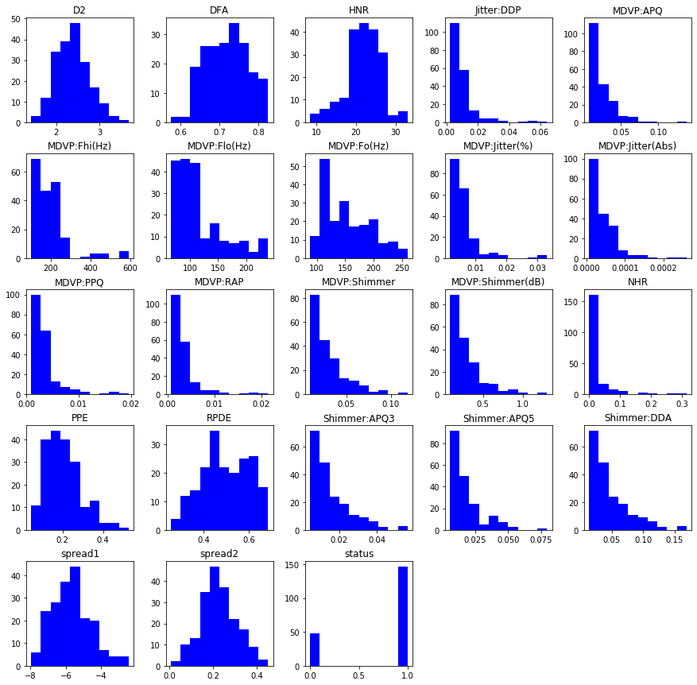

```python
#Ploting histogram to check that if data columns are normal or almost normal or not
df.hist(figsize=(15,15),color="blue",grid=False)
plt.show()
```

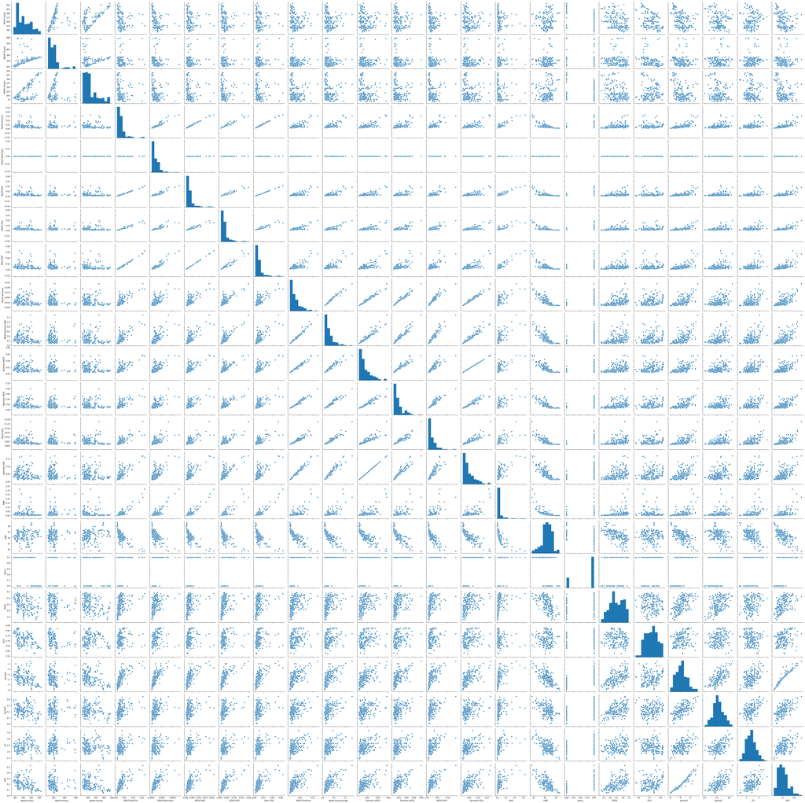

```python
# Pair Plot
sns.pairplot(df.iloc[:,1:])
```

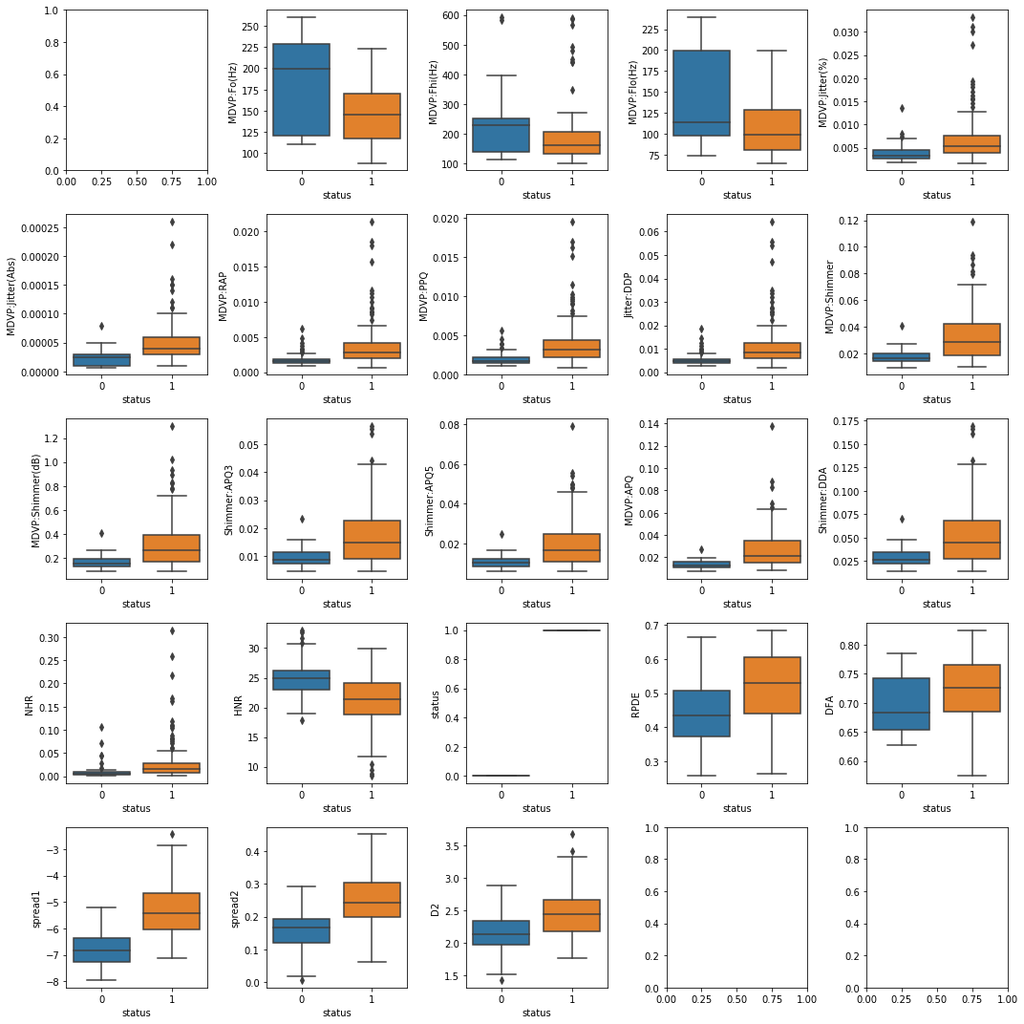

```python
# Box Plot to check outliers
fig,axes=plt.subplots(5,5,figsize=(15,15))
axes=axes.flatten()

for i in range(1,len(df.columns)-1):
    sns.boxplot(x='status',y=df.iloc[:,i],data=df,orient='v',ax=axes[i])
plt.tight_layout()
plt.show()
```

```python
# Measuring skewness
# We see that most of the features are heavily skewed to the right
df.skew(axis = 0, skipna = True)
```

```
MDVP:Fo(Hz)         0.591737
MDVP:Fhi(Hz)        2.542146
MDVP:Flo(Hz)        1.217350
MDVP:Jitter(%)      3.084946
MDVP:Jitter(Abs)    2.649071
MDVP:RAP            3.360708
MDVP:PPQ            3.073892
Jitter:DDP          3.362058
MDVP:Shimmer        1.666480
MDVP:Shimmer(dB)    1.999389
Shimmer:APQ3        1.580576
Shimmer:APQ5        1.798697
MDVP:APQ            2.618047
Shimmer:DDA         1.580618
NHR                 4.220709
HNR                -0.514317
status             -1.187727
RPDE               -0.143402
DFA                -0.033214
spread1             0.432139
spread2             0.144430
D2                  0.430384
PPE                 0.797491
dtype: float64
```

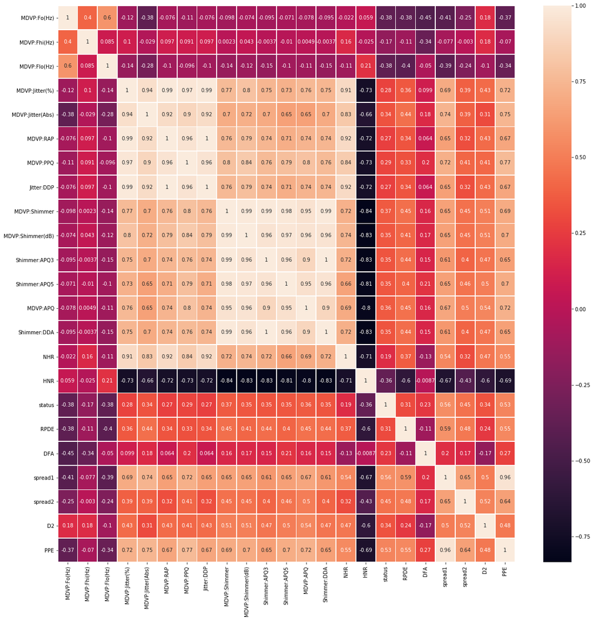

```python
corr = df.corr()
fig, axs = plt.subplots(figsize=(20,20))
sns.heatmap(corr, annot=True, linewidths=.8, ax=axs)
```

##### Inferences:

1. There are lot of correlated data. The range of data in every attribute is totally different and arriving at a common scale would be a challenge.Standardization should be applied.

Hence,dropping Columns with strong positive correlation: 'MDVP:Jitter(Abs)', 'MDVP:RAP', 'MDVP:PPQ', 'Jitter:DDP','MDVP:Shimmer(dB)', 'Shimmer:APQ3', 'Shimmer:APQ5', 'MDVP:APQ', 'Shimmer:DDA','spread1','NHR'

1. We see that most of the features are heavily skewed to the right showing the presence of lot of outliers. Hence Outlier treatment should be done to achieve consistency in the data.

```python
#function to treat outliers in the features using IQR
#Removing the outliers of (MDVP:Fo(Hz), RPDE, DFA, spread2, D2, PPE)
def outlier_correction(df):
  outlier_features = ['MDVP:Fo(Hz)', 'RPDE', 'DFA',  'spread2', 'D2', 'PPE']
  for col in outlier_features:
    p = np.percentile(df[col], [25, 75])
    iqr = p[1]-p[0]
    df.loc[:, col].clip(lower = p[0]-1.5*iqr, upper = p[1]+1.5*iqr, inplace = True)
  return df
FunctionTransformer(outlier_correction)
```

```
FunctionTransformer(accept_sparse=False, check_inverse=True,
                    func=<function outlier_correction at 0x000002662F3B73A8>,
                    inv_kw_args=None, inverse_func=None, kw_args=None,
                    validate=False)
```

```python
df_dropped = df.drop(['MDVP:Jitter(Abs)', 'MDVP:RAP', 'MDVP:PPQ', 'Jitter:DDP','MDVP:Shimmer(dB)', 'Shimmer:APQ3',
 'Shimmer:APQ5', 'MDVP:APQ', 'Shimmer:DDA','spread1','NHR'],axis=1)
```

```python
# After dropping columns with strong positive correlation
df_dropped.columns
```

```
Index(['name', 'MDVP:Fo(Hz)', 'MDVP:Fhi(Hz)', 'MDVP:Flo(Hz)', 'MDVP:Jitter(%)',
       'MDVP:Shimmer', 'HNR', 'status', 'RPDE', 'DFA', 'spread2', 'D2', 'PPE'],
      dtype='object')
```

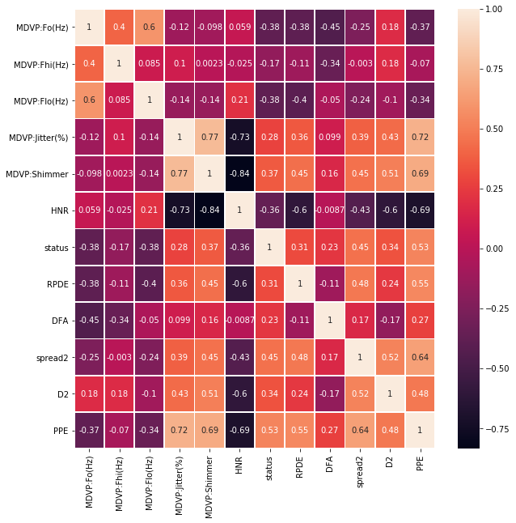

```python
fig, axs = plt.subplots(figsize=(10,10))
sns.heatmap(df_dropped.corr(), annot=True, linewidths=.8, ax=axs)
```

```python
# The target column is imbalanced as we have more dieseased people in dataset.
df_dropped['status'].value_counts()
```

```
1    147
0     48
Name: status, dtype: int64
```

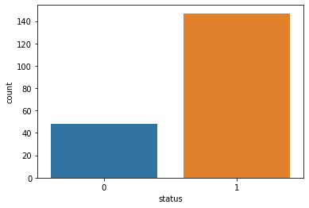

```python
#ploting the count of the target variable
sns.countplot(df['status'])
plt.show()
```

```python
data1=df_dropped[['MDVP:Fo(Hz)','MDVP:Fhi(Hz)','MDVP:Flo(Hz)','MDVP:Jitter(%)','MDVP:Shimmer','HNR','RPDE','DFA','spread2','D2','PPE','status']]
data1.head(10)
```

|  | MDVP:Fo(Hz) | MDVP:Fhi(Hz) | MDVP:Flo(Hz) | MDVP:Jitter(%) | MDVP:Shimmer | HNR | RPDE | DFA | spread2 | D2 | PPE | status |
| --- | --- | --- | --- | --- | --- | --- | --- | --- | --- | --- | --- | --- |
| 0 | 119.992 | 157.302 | 74.997 | 0.00784 | 0.04374 | 21.033 | 0.414783 | 0.815285 | 0.266482 | 2.301442 | 0.284654 | 1 |
| 1 | 122.400 | 148.650 | 113.819 | 0.00968 | 0.06134 | 19.085 | 0.458359 | 0.819521 | 0.335590 | 2.486855 | 0.368674 | 1 |
| 2 | 116.682 | 131.111 | 111.555 | 0.01050 | 0.05233 | 20.651 | 0.429895 | 0.825288 | 0.311173 | 2.342259 | 0.332634 | 1 |
| 3 | 116.676 | 137.871 | 111.366 | 0.00997 | 0.05492 | 20.644 | 0.434969 | 0.819235 | 0.334147 | 2.405554 | 0.368975 | 1 |
| 4 | 116.014 | 141.781 | 110.655 | 0.01284 | 0.06425 | 19.649 | 0.417356 | 0.823484 | 0.234513 | 2.332180 | 0.410335 | 1 |
| 5 | 120.552 | 131.162 | 113.787 | 0.00968 | 0.04701 | 21.378 | 0.415564 | 0.825069 | 0.299111 | 2.187560 | 0.357775 | 1 |
| 6 | 120.267 | 137.244 | 114.820 | 0.00333 | 0.01608 | 24.886 | 0.596040 | 0.764112 | 0.257682 | 1.854785 | 0.211756 | 1 |
| 7 | 107.332 | 113.840 | 104.315 | 0.00290 | 0.01567 | 26.892 | 0.637420 | 0.763262 | 0.183721 | 2.064693 | 0.163755 | 1 |
| 8 | 95.730 | 132.068 | 91.754 | 0.00551 | 0.02093 | 21.812 | 0.615551 | 0.773587 | 0.327769 | 2.322511 | 0.231571 | 1 |
| 9 | 95.056 | 120.103 | 91.226 | 0.00532 | 0.02838 | 21.862 | 0.547037 | 0.798463 | 0.325996 | 2.432792 | 0.271362 | 1 |

```python
data1.shape
```

```
(195, 12)
```

```python
data1["status"].value_counts(normalize=True)
```

```
1    0.753846
0    0.246154
Name: status, dtype: float64
```

## 5. Spliting the dataset into training and test set in the ratio of 70:30

```python
array = data1.values
X = array[:,0:10] # select all rows and first 11 columns which are the attributes
Y = array[:,11]   # select all rows and the 12th column which is the classification "0", "1"
test_size = 0.30 # taking 70:30 training and test set
X_train, X_test, y_train, y_test = train_test_split(X, Y, test_size=test_size, random_state=1) # To set the random state
type(X_train)
```

```
numpy.ndarray
```

## 6. Training three standard classification algorithms

### 6a. Applying Logistic Regression

```python
# Fit the model on 30%
model = LogisticRegression(solver="liblinear")
model.fit(X_train, y_train)
y_predict = model.predict(X_test)
model_score = model.score(X_test, y_test)
print('Accuracy:',model_score)
print('confusion_matrix:')
print(metrics.confusion_matrix(y_test, y_predict))
A=model_score  # Accuracy of Logistic regression model
```

```
Accuracy: 0.8135593220338984
confusion_matrix:
[[ 9 10]
 [ 1 39]]
```

### 6b.Applying Naive-Bayes model

```python
# Applying Naive-Bayes
from sklearn.impute import SimpleImputer
imputer = SimpleImputer(missing_values=np.nan, strategy='mean')
from sklearn import preprocessing
from sklearn.naive_bayes import GaussianNB
from sklearn.metrics import accuracy_score
```

```python
X = data1.values[:,0:10]  ## Features
Y = data1.values[:,11]  ## Target.values[:,11]  ## Target
```

```python
X_train, X_test, Y_train, Y_test = train_test_split(X, Y, test_size = 0.30, random_state = 2)
```

```python
clf = GaussianNB()
clf.fit(X_train, Y_train)
```

```
GaussianNB(priors=None, var_smoothing=1e-09)
```

```python
Y_pred = clf.predict(X_test)
```

```python
B=accuracy_score(Y_test, Y_pred, normalize = True) #Accuracy of Naive Bayes' Model
print('Accuracy_score:',B)
```

```
Accuracy_score: 0.6949152542372882
```

```python
from sklearn.metrics import recall_score
print(recall_score(Y_test, Y_pred))
```

```
0.6808510638297872
```

```python
print('Confusion_matrix:')
print(metrics.confusion_matrix(Y_test,Y_pred))
```

```
Confusion_matrix:
[[ 9  3]
 [15 32]]
```

### 6c. Applying K-NN model

```python
# Applying K-NN

from sklearn import preprocessing
from sklearn.preprocessing import StandardScaler
```

```python
X_std = pd.DataFrame(StandardScaler().fit_transform(data1))
X_std.columns = data1.columns
```

```python
#spliting the dataset into training and test datasets
import numpy as np
from sklearn.model_selection import train_test_split
```

```python
# Transform data into features and target
X = np.array(data1.iloc[:,1:11])
y = np.array(data1['status'])
```

```python
# split into train and test
X_train, X_test, y_train, y_test = train_test_split(X, y, test_size=0.3, random_state=3)
```

```python
print(X_train.shape)
print(y_train.shape)
```

```
(136, 10)
(136,)
```

```python
print(X_test.shape)
print(y_test.shape)
```

```
(59, 10)
(59,)
```

```python
# loading library
from sklearn.neighbors import KNeighborsClassifier
from sklearn.metrics import accuracy_score
from sklearn.metrics import recall_score
```

```python
# instantiate learning model (k = 1)
knn = KNeighborsClassifier(n_neighbors = 1)
# fitting the model
knn.fit(X_train, y_train)
# predict the response
y_pred = knn.predict(X_test)
# evaluate accuracy
print(accuracy_score(y_test, y_pred))
```

```
0.7796610169491526
```

```python
# instantiate learning model (k = 5)
knn = KNeighborsClassifier(n_neighbors = 5)
# fitting the model
knn.fit(X_train, y_train)
# predict the response
y_pred = knn.predict(X_test)
# evaluate accuracy
print(accuracy_score(y_test, y_pred))
```

```
0.7796610169491526
```

```python
# instantiate learning model (k = 3)
knn = KNeighborsClassifier(n_neighbors = 3)
# fitting the model
knn.fit(X_train, y_train)
# predict the response
y_pred = knn.predict(X_test)
# evaluate accuracy
print(accuracy_score(y_test, y_pred))
```

```
0.7966101694915254
```

```python
# instantiate learning model (k = 7)
knn = KNeighborsClassifier(n_neighbors = 7)
# fitting the model
knn.fit(X_train, y_train)
# predict the response
y_pred = knn.predict(X_test)
# evaluate accuracy
print(accuracy_score(y_test, y_pred))
```

```
0.8135593220338984
```

```python
myList = list(range(1,20))

# subsetting just the odd ones
neighbors = list(filter(lambda x: x % 2 != 0, myList))
ac_scores = []
# perform accuracy metrics for values from 1,3,5....19
for k in neighbors:
    knn = KNeighborsClassifier(n_neighbors=k)
    knn.fit(X_train, y_train)
    # predict the response
    y_pred = knn.predict(X_test)
    # evaluate accuracy
    scores = accuracy_score(y_test, y_pred)
    ac_scores.append(scores)

# changing to misclassification error
MSE = [1 - x for x in ac_scores]

# determining best k
optimal_k = neighbors[MSE.index(min(MSE))]
print("The optimal number of neighbors is %d" % optimal_k)
```

```
The optimal number of neighbors is 9
```

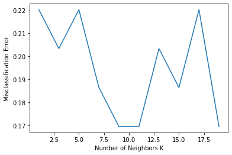

```python
#Plot misclassification error vs k (with k value on X-axis) using matplotlib.
import matplotlib.pyplot as plt
# plot misclassification error vs k
plt.plot(neighbors, MSE)
plt.xlabel('Number of Neighbors K')
plt.ylabel('Misclassification Error')
plt.show()
```

```python
#Use k=9 as the final model for prediction
knn = KNeighborsClassifier(n_neighbors = 9)

# fitting the model
knn.fit(X_train, y_train)

# predict the response
y_pred = knn.predict(X_test)

# evaluate accuracy
C=accuracy_score(y_test, y_pred)   #Accuracy of KNN model
print('Accuracy_score:',C)
print(recall_score(y_test, y_pred))
```

```
Accuracy_score: 0.8305084745762712
0.8913043478260869
```

```python
print('Confusion_matrix:')
print(metrics.confusion_matrix(y_test, y_pred))
```

```
Confusion_matrix:
[[ 8  5]
 [ 5 41]]
```

```python
# Comparison of Logistic, Naive-Bayes & KNN models
print(A)#Accuracy of Logistic regression model
```

```
0.8135593220338984
```

```python
print(B)#Accuracy of Naive-Bayes model
```

```
0.6949152542372882
```

```python
print(C)#Accuracy of K-NN model
```

```
0.8305084745762712
```

### Inference : K-NN model performs well when compared to Logistic Regression & Naive-Bayes model for the given dataset

## 7. Training Meta Classifier & checking accuracy in test data

```python
X = data1.values[:,0:10]  ## Features
Y = data1.values[:,11]  ## Target.values[:,11]  ## Target

clf1 = KNeighborsClassifier(n_neighbors=9)
clf2 = RandomForestClassifier(random_state=1)
clf3 = GaussianNB()
lr = LogisticRegression()
sclf = StackingClassifier(classifiers=[clf1, clf2, clf3],
                          meta_classifier=lr)

print('3-fold cross validation:\n')

for clf, label in zip([clf1, clf2, clf3, sclf],
                      ['KNN',
                       'Random Forest',
                       'Naive Bayes',
                       'StackingClassifier']):

    scores = model_selection.cross_val_score(clf, X, y,
                                              cv=3, scoring='accuracy')
    print("Accuracy: %0.2f (+/- %0.2f) [%s]"
          % (scores.mean(), scores.std(), label))
```

```
3-fold cross validation:

Accuracy: 0.81 (+/- 0.03) [KNN]
Accuracy: 0.83 (+/- 0.04) [Random Forest]
Accuracy: 0.72 (+/- 0.01) [Naive Bayes]
Accuracy: 0.83 (+/- 0.04) [StackingClassifier]
```

## 8. Training Ensemble Models

### 8a.Creating the decision tree model using “entropy” method

```python
from sklearn.tree import DecisionTreeClassifier
dt_model = DecisionTreeClassifier(criterion = 'entropy' )
dt_model.fit(X_train, y_train)
```

```
DecisionTreeClassifier(ccp_alpha=0.0, class_weight=None, criterion='entropy',
                       max_depth=None, max_features=None, max_leaf_nodes=None,
                       min_impurity_decrease=0.0, min_impurity_split=None,
                       min_samples_leaf=1, min_samples_split=2,
                       min_weight_fraction_leaf=0.0, presort='deprecated',
                       random_state=None, splitter='best')
```

```python
dt_model.score(X_train, y_train)# performance on train data
```

```
1.0
```

```python
dt_model.score(X_test, y_test)  # performance on test data
```

```
0.847457627118644
```

#### Inference : There is a high degree of overfitting in the model due to which the test accuracy drops drastically

##### Action taken: Regularize/prune the decision tree by limiting the max. depth of trees and print the accuracy

```python
clf_pruned = DecisionTreeClassifier(criterion = "entropy", random_state = 1,
                               max_depth=3, min_samples_leaf=5)
clf_pruned.fit(X_train, y_train)
```

```
DecisionTreeClassifier(ccp_alpha=0.0, class_weight=None, criterion='entropy',
                       max_depth=3, max_features=None, max_leaf_nodes=None,
                       min_impurity_decrease=0.0, min_impurity_split=None,
                       min_samples_leaf=5, min_samples_split=2,
                       min_weight_fraction_leaf=0.0, presort='deprecated',
                       random_state=1, splitter='best')
```

```python
preds_pruned = clf_pruned.predict(X_test)
preds_pruned_train = clf_pruned.predict(X_train)
```

```python
print(accuracy_score(y_test,preds_pruned))
print(accuracy_score(y_train,preds_pruned_train))
```

```
0.847457627118644
0.9191176470588235
```

```python
acc_DT = accuracy_score(y_test, preds_pruned)
```

##### Inference: When the tree is regularaised, overfitting is reduced, but there is no increase in accuracy

```python
## Calculating feature importance

xvar = data1.drop('status', axis=1)
feature_cols = xvar.columns

feat_importance = clf_pruned.tree_.compute_feature_importances(normalize=False)
feat_imp_dict = dict(zip(feature_cols, clf_pruned.feature_importances_))
feat_imp = pd.DataFrame.from_dict(feat_imp_dict, orient='index')
feat_imp.sort_values(by=0, ascending=False)
```

|  | 0 |
| --- | --- |
| D2 | 0.545907 |
| MDVP:Jitter(%) | 0.153267 |
| RPDE | 0.119622 |
| MDVP:Fo(Hz) | 0.105635 |
| spread2 | 0.075569 |
| MDVP:Fhi(Hz) | 0.000000 |
| MDVP:Flo(Hz) | 0.000000 |
| MDVP:Shimmer | 0.000000 |
| HNR | 0.000000 |
| DFA | 0.000000 |

```python
#Store the accuracy results for each model in a dataframe for final comparison
resultsDf = pd.DataFrame({'Method':['Decision Tree'], 'accuracy': acc_DT})
resultsDf = resultsDf[['Method', 'accuracy']]
resultsDf
```

|  | Method | accuracy |
| --- | --- | --- |
| 0 | Decision Tree | 0.847458 |

### 8b. Apply the Random forest model and print the accuracy of Random forest Model

```python
from sklearn.ensemble import RandomForestClassifier
rfcl = RandomForestClassifier(n_estimators = 50)
rfcl = rfcl.fit(X_train, y_train)
```

```python
pred_RF = rfcl.predict(X_test)
acc_RF = accuracy_score(y_test, pred_RF)
```

```python
tempResultsDf = pd.DataFrame({'Method':['Random Forest'], 'accuracy': [acc_RF]})
resultsDf = pd.concat([resultsDf, tempResultsDf])
resultsDf = resultsDf[['Method', 'accuracy']]
resultsDf
resultsDf
```

|  | Method | accuracy |
| --- | --- | --- |
| 0 | Decision Tree | 0.847458 |
| 0 | Random Forest | 0.864407 |

### 8c.Apply Adaboost Ensemble Algorithm for the same data and print the accuracy

```python
from sklearn.ensemble import AdaBoostClassifier
abcl = AdaBoostClassifier( n_estimators= 100, learning_rate=0.1, random_state=22)
abcl = abcl.fit(X_train, y_train)
```

```python
pred_AB =abcl.predict(X_test)
acc_AB = accuracy_score(y_test, pred_AB)
```

```python
tempResultsDf = pd.DataFrame({'Method':['Adaboost'], 'accuracy': [acc_AB]})
resultsDf = pd.concat([resultsDf, tempResultsDf])
resultsDf = resultsDf[['Method', 'accuracy']]
resultsDf
resultsDf
```

|  | Method | accuracy |
| --- | --- | --- |
| 0 | Decision Tree | 0.847458 |
| 0 | Random Forest | 0.864407 |
| 0 | Adaboost | 0.830508 |

##### Inference: Adaboost classifier did not perform better than Decision tree and Random forest

### 8d. Apply Bagging Classifier Algorithm and print the accuracy

```python
from sklearn.ensemble import BaggingClassifier

bgcl = BaggingClassifier(n_estimators=50, max_samples= .7, bootstrap=True, oob_score=True, random_state=22)
bgcl = bgcl.fit(X_train, y_train)
```

```python
pred_BG =bgcl.predict(X_test)
acc_BG = accuracy_score(y_test, pred_BG)
```

```python
tempResultsDf = pd.DataFrame({'Method':['Bagging'], 'accuracy': [acc_BG]})
resultsDf = pd.concat([resultsDf, tempResultsDf])
resultsDf = resultsDf[['Method', 'accuracy']]
resultsDf
resultsDf
```

|  | Method | accuracy |
| --- | --- | --- |
| 0 | Decision Tree | 0.847458 |
| 0 | Random Forest | 0.864407 |
| 0 | Adaboost | 0.830508 |
| 0 | Bagging | 0.898305 |

##### Inference: Bagging performs better compared to Random Forest, Decision Tree and Adaboost

### 8e. Apply GradientBoost Classifier Algorithm for the same data and print the accuracy

```python
from sklearn.ensemble import GradientBoostingClassifier
gbcl = GradientBoostingClassifier(n_estimators = 50, learning_rate = 0.1, random_state=22)
gbcl = gbcl.fit(X_train, y_train)
```

```python
pred_GB =gbcl.predict(X_test)
acc_GB = accuracy_score(y_test, pred_GB)
```

```python
tempResultsDf = pd.DataFrame({'Method':['Gradient Boost'], 'accuracy': [acc_GB]})
resultsDf = pd.concat([resultsDf, tempResultsDf])
resultsDf = resultsDf[['Method', 'accuracy']]
resultsDf
resultsDf
```

|  | Method | accuracy |
| --- | --- | --- |
| 0 | Decision Tree | 0.847458 |
| 0 | Random Forest | 0.864407 |
| 0 | Adaboost | 0.830508 |
| 0 | Bagging | 0.898305 |
| 0 | Gradient Boost | 0.915254 |

## 9. Comparing & Picking the best ensemble model among the models used

### Conclusion: Among Ensemble models used, Gradient Boost model has given the best results on test predictions